# C++ Programming Guideline(V17.01)

autor:ichiroprogrammer

# 17 deps

本ドキュメントでは、いくつかの場所でパッケージ間の依存関係の重要性について説明したため、 これに従って開発を行うのであれば、依存関係の維持、監視が必要になる。

そのための市販のツールを購入することもできるが、 やりたいことと完全にマッチしたものがあるわけではないため、 このドキュメント専用のツールdepsを開発した。

このようなツールの開発にはpythonやrubyが適しているが、 このドキュメントの目的に合わせて、depsは下記のようにC++で書かれている。

| ファイル名 | 機能、目的 |
| --- | --- |
| example/deps/app/ | depsのメインディレクト |
| “example/deps/app/src/main.cpp” | depsのmain関数を含むファイル |
| “example/deps/app/src/deps_opts.cpp” | depsのオプション処理 |
| “example/deps/app/src/deps_opts.h” | deps_opts.cppのヘッダ |
| “example/deps/app/ut/deps_opts_ut.cpp” | deps_opts.cppの単体テスト |
| example/deps/dependency/ | deps_scenario.a用のディレクトリ |
| “example/deps/dependency/h/deps_scenario.h” | deps_scenario.aの外部公開ヘッダ |
| “example/deps/dependency/src/arch_pkg.cpp” | パッケージの依存関係 |
| “example/deps/dependency/src/arch_pkg.h” | arch_pkg.cppのヘッダ |
| “example/deps/dependency/src/cpp_deps.cpp” | ファイル間依存関係 |
| “example/deps/dependency/src/cpp_deps.h” | cpp_deps.cppのヘッダ |
| “example/deps/dependency/src/cpp_dir.cpp” | C++ファイルを含むディレクトリ抽出 |
| “example/deps/dependency/src/cpp_dir.h” | cpp_dir.cppのヘッダ |
| “example/deps/dependency/src/cpp_src.cpp” | C++ファイルの抽出 |
| “example/deps/dependency/src/cpp_src.h” | cpp_src.cppのヘッダ |
| “example/deps/dependency/src/deps_scenario.cpp” | 依存関係表示のシナリオ |
| “example/deps/dependency/src/load_store_format.cpp” | deps生成ファイルのロード/ストア |
| “example/deps/dependency/src/load_store_format.h” | load_store_format.cppのヘッダ |
| “example/deps/dependency/ut/arch_pkg_ut.cpp” | arch_pkg.cppの単体テスト |
| “example/deps/dependency/ut/cpp_deps_ut.cpp” | cpp_deps.cppの単体テスト |
| “example/deps/dependency/ut/cpp_dir_ut.cpp” | cpp_dir.cppの単体テスト |
| “example/deps/dependency/ut/cpp_src_ut.cpp” | cpp_src.cppの単体テスト |
| “example/deps/dependency/ut/deps_scenario_ut.cpp” | deps_scenario.cppの単体テスト |
| “example/deps/dependency/ut/load_store_format_ut.cpp” | load_store_format.cppの単体テスト |
| example/deps/file_utils/ | file_utils.a用のディレクトリ |
| “example/deps/file_utils/h/load_store.h” | ファイルのロード/ストア |
| “example/deps/file_utils/h/load_store_row.h” | load_store_row.cppのヘッダ |
| “example/deps/file_utils/h/path_utils.h” | path_utils.cppのヘッダ |
| “example/deps/file_utils/src/load_store_row.cpp” | ファイルののロード/ストア |
| “example/deps/file_utils/src/path_utils.cpp” | ファイル操作 |
| “example/deps/file_utils/ut/load_store_row_ut.cpp” | load_store_row.cppの単体テスト |
| “example/deps/file_utils/ut/path_utils_ut.cpp” | path_utils.cppの単体テスト |
| example/deps/lib/ |  |
| “example/deps/lib/h/nstd.h” | 一般的なテンプレート |
| “example/deps/lib/ut/nstd_ut.cpp” | nstd.hの単体テスト |
| example/deps/logging/ | logging.a用のディレクトリ |
| “example/deps/logging/h/logger.h” | logger.cppのヘッダ |
| “example/deps/logging/src/logger.cpp” | ログの取得 |
| “example/deps/logging/ut/logger_ut.cpp” | logger.cppの単体テスト |

## 17.1 depsの構造

depsのソースコードやそのディレクトリは、

| ディレクトリ名 | 目的 |
| --- | --- |
| */src | cppファイルとパッケージ内部用ヘッダ |
| */h | パッケージ外部公開用ヘッダ |
| */ut | このパッケージの単体テスト |

のように配置されており、src、h、ut をその一つ上の階層で括ったディレクトリをパッケージとみなした場合の依存関係は、

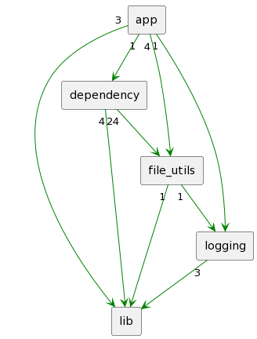

のようになっている。

当然ながら、「パッケージとその構成ファイル」で述べた構造と相似である。

なお、utディレクトリを別パッケージとした場合の依存関係は、

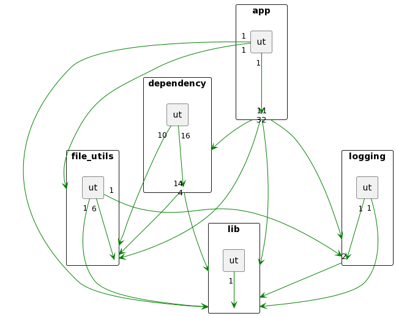

のようになっており、整理された依存関係であるといえる。

自分が開発しているソースコードの整理をする場合、depsの構造を真似れば、 大きく失敗することは少ない。

## 17.2 depsの使い方

depsのコマンドオプションを以下に示す。

```
    deps CMD [option] [DIRS] ...
       CMD:
             p    : generate package to OUT.
             s    : generate srcs with incs to OUT.
             p2s  : generate package and srcs pairs to OUT.
             p2p  : generate packages' dependencies to OUT.
             a    : generate structure to OUT from p2p output.
             a2pu : generate plant uml package to OUT from p2p output.
             cyc  : exit !0 if found cyclic dependencies.
             help : show help message.
             h    : same as help(-h, --help).

       opptions:
             --in IN     : use IN to execute CMD.
             --out OUT   : CMD outputs to OUT.
             --recursive : search dir as package from DIRS or IN contents.
             -R          : same as --recursive.
             --src_as_pkg: every src is as a package.
             -s          : same as --src_as_pkg.
             --log LOG   : loggin to LOG(if LOG is "-", using STDOUT).
             --exclude PTN : exclude dirs which matchs to PTN(JS regex).
             -e PTN      : same as --exclude.

       DIRS: use DIRS to execute CMD.
       IN  : 1st line in this file must be
                 #dir2srcs for pkg-srcs file
             or
                 #dir for pkg file.
```

各ユースケース

- ユースケース-循環依存を発見した場合、非0でexitする
- ユースケース-C++のソースコードを含むディレクトリを探す
- ユースケース-ディレクトリをパッケージとみなして、パッケージとソースコードの関係を示す
- ユースケース-パッケージ間の依存関係を示す
- ユースケース-パッケージ間の依存関係を構造的に表す
- ユースケース-パッケージ間の依存関係をplant umlで表す
- ユースケース-ソースコード間の依存関係をplant umlで表す
- ユースケース-パッケージでないディレクトリをそれとみなさない

におけるdepsの使い方や出力等を示す。

### 17.2.1 ユースケース-循環依存を発見した場合、非0でexitする

このツールの主な目的は、パッケージ間の循環依存を検出することである。 このユースケースは、これを実現する方法を提示する。

```
    > ./g++/deps p2p -R -s --out p2p.txt ut_data/
    > ./g++/deps cyc --in p2p.txt
```

CIのチェック項目(「CI(継続的インテグレーション)」参照)に上記を導入することで、 循環の無い依存関係を維持することができる。

下記に、「ディレクトリが必ずしもパッケージに対応するわけではない」場合の対処法を掲載する。

### 17.2.2 ユースケース-C++のソースコードを含むディレクトリを探す

以下のコマンドは、CMD pによりut_data/配下のソースコードを含むディレクトリを探す。

```
    > ./g++/deps p -R ut_data/
```

アウトプットは以下のようになる。

```
    #dir
    ut_data/app1
    ut_data/app1/mod1
    ut_data/app1/mod2
    ut_data/app1/mod2/mod2_1
    ut_data/app1/mod2/mod2_2
    ut_data/app2
```

–out OUT-FILEを指定すれば、上記出力はOUT-FILEに書き出される。 OUT-FILEを適切に編集し、他のCMDの入力(–in IN-FILE)に使用することもできる。

### 17.2.3 ユースケース-ディレクトリをパッケージとみなして、パッケージとソースコードの関係を示す

以下のコマンドは、CMD p2sによりut_data配下のディレクトリをパッケージとみなして、 パッケージとソースコードの関係を出力する。

```
    > ./g++/deps p2s -R ut_data/
```

アウトプットは以下のようになる。

```
    #dir2srcs
    ut_data/app1
        ut_data/app1/a_1_c.c
        ut_data/app1/a_1_c.h
        ut_data/app1/a_1_cpp.cpp
        ut_data/app1/a_1_cpp.h

    ... 中略 ...

    ut_data/app1/mod2/mod2_2
        ut_data/app1/mod2/mod2_2/mod2_2_1.cpp
        ut_data/app1/mod2/mod2_2/mod2_2_1.h

    ut_data/app2
        ut_data/app2/b_1.cpp
        ut_data/app2/b_1.h
```

### 17.2.4 ユースケース-パッケージ間の依存関係を示す

以下のコマンドは、CMD p2pによりdeps/ut_data配下のパッケージとの依存関係をp2p.txtに出力する。

```
    > cd ./deps
    > ./g++/deps p2p -R --out p2p.txt ut_data/
```

アウトプットは以下のようになる。

```
    #deps
    ut_data/app1 -> ut_data/app1/mod1 : 2 ut_data/app1/mod1/mod1_1.hpp ut_data/app1/mod1/mod1_2.hpp
    ut_data/app1/mod1 -> ut_data/app1 : 0

    ut_data/app1 -> ut_data/app1/mod2 : 0
    ut_data/app1/mod2 -> ut_data/app1 : 0

    ... 中略 ...

    ut_data/app1/mod2 -> ut_data/app2 : 0
    ut_data/app2 -> ut_data/app1/mod2 : 0

    ut_data/app1/mod2/mod2_1 -> ut_data/app1/mod2/mod2_2 : 1 ut_data/app1/mod2/mod2_2/mod2_2_1.h
    ut_data/app1/mod2/mod2_2 -> ut_data/app1/mod2/mod2_1 : 2 ut_data/app1/mod2/mod2_1/mod2_1_1.h

    ut_data/app1/mod2/mod2_1 -> ut_data/app2 : 0
    ut_data/app2 -> ut_data/app1/mod2/mod2_1 : 0

    ut_data/app1/mod2/mod2_2 -> ut_data/app2 : 0
    ut_data/app2 -> ut_data/app1/mod2/mod2_2 : 0
```

例を上げて、上記の意味を説明する。

[例]

```
    ut_data/app1/mod2/mod2_1 -> ut_data/app1/mod2/mod2_2 : 1 ut_data/app1/mod2/mod2_2/mod2_2_1.h
    ut_data/app1/mod2/mod2_2 -> ut_data/app1/mod2/mod2_1 : 2 ut_data/app1/mod2/mod2_1/mod2_1_1.h
```

[例の意味]

- ut_data/app1/mod2/mod2_1からut_data/app1/mod2/mod2_2への依存ファイルは ut_data/app1/mod2/mod2_2/mod2_2_1.hで、1箇所includeされている。
- ut_data/app1/mod2/mod2_2からut_data/app1/mod2/mod2_1の依存ファイルは ut_data/app1/mod2/mod2_1/mod2_1_1.hで、2箇所includeされている。

### 17.2.5 ユースケース-パッケージ間の依存関係を構造的に表す

以下のコマンドは、CMD aにより上記p2p.txtを構造的に出力する。

```
    > ./g++/deps a  --in p2p.txt
```

アウトプットは以下のようになる。

```
    #arch
    package  :app1:CYCLIC
    parent   :TOP
    depend_on: {
        mod1 : CYCLIC
    }
    children : {
        package  :mod1:CYCLIC
        parent   :app1
        depend_on: {
            mod2 : STRAIGHT
            mod2_2 : CYCLIC
        }
        children : { }

        package  :mod2
        parent   :app1
        depend_on: { }
        children : {
            package  :mod2_1:CYCLIC
            parent   :mod2
            depend_on: {
                mod2_2 : CYCLIC
            }
            children : { }

            package  :mod2_2:CYCLIC
            parent   :mod2
            depend_on: {
                app1 : CYCLIC
                mod2_1 : CYCLIC
            }
            children : { }
        }
    }

    package  :app2
    parent   :TOP
    depend_on: {
        app1 : STRAIGHT
        mod1 : STRAIGHT
    }
    children : { }
```

ディレクトリ名の後ろの

- STRAIGHTは依存関係が循環していない
- CYCLICは依存関係が循環している

ことを示している。

### 17.2.6 ユースケース-パッケージ間の依存関係をplant umlで表す

以下のコマンドは、CMD a2puにより上記p2p.txtをplant uml形式で出力する。

```
    > ./g++/deps a2pu  --in p2p.txt
```

アウトプットは以下のようになる。

```
    @startuml
    scale max 730 width
    rectangle "app1" as ut_data___app1 {
        rectangle "mod1" as ut_data___app1___mod1
        rectangle "mod2" as ut_data___app1___mod2 {
            rectangle "mod2_1" as ut_data___app1___mod2___mod2_1
            rectangle "mod2_2" as ut_data___app1___mod2___mod2_2
        }
    }
    rectangle "app2" as ut_data___app2

    ut_data___app1 "6" <-[#red]-> "1" ut_data___app1___mod1
    ut_data___app1 "3" <-[#red]-> "1" ut_data___app1___mod2___mod2_1
    ut_data___app1 "3" <-[#red]-> "2" ut_data___app1___mod2___mod2_2
    ut_data___app2 "3" -[#green]-> ut_data___app1
    ut_data___app1___mod1 "1" -[#green]-> ut_data___app1___mod2
    ut_data___app1___mod1 "1" <-[#red]-> "2" ut_data___app1___mod2___mod2_1
    ut_data___app1___mod1 "1" <-[#red]-> "4" ut_data___app1___mod2___mod2_2
    ut_data___app2 "4" -[#green]-> ut_data___app1___mod1
    ut_data___app1___mod2___mod2_1 "1" <-[#red]-> "2" ut_data___app1___mod2___mod2_2
    ut_data___app2 "2" -[#green]-> ut_data___app1___mod2___mod2_1
    ut_data___app2 "2" -[#green]-> ut_data___app1___mod2___mod2_2

    @enduml
```

このアウトプットを[plant umlオンラインジェネレータ](http://www.plantuml.com/plantuml/) のテキストボックスに貼り付ければpngファイルが得られ、視覚的に依存関係を把握できる。

### 17.2.7 ユースケース-ソースコード間の依存関係をplant umlで表す

ソースコードをパッケージとみなすオプション(-sもしくは–src_as_pkg)を付加して、 これまでの説明と同様のことを行うと、

```
    > ./g++/deps p2p -R -s --out p2p.txt ut_data/
    > ./g++/deps a2pu  --in p2p.txt --out p2p.pu
```

ソースコードの依存関係がplant uml形式で得られる。

### 17.2.8 ユースケース-パッケージでないディレクトリをそれとみなさない

depsのソースコードを含むdependency/hは、 dependencyパッケージのインターフェースを外部公開するためのものであり、 dependencyのサブパッケージではない。 このような場合、dependency/h/deps_scenario.hのようなファイルは、 dependencyに直接属するように扱うべきであるが、 このツールがファイル構造からそれを読み解くことは不可能である。

このような場合に対処する方法は下記の3通りある。

- -Rを指定せず、パッケージとなる全ディレクトリをINに記述する。
- pコマンドで候補ディレクトリを全てファイルに出力し、 パッケージでないディレクトリをそのファイルから削除した後、 そのファイルをINファイルとしてp2pコマンド等を使う。
- –exclude PTNでパッケージ対象でないディレクトリを指定しp2pコマンド等を使う。 なお、例えばhディレクトリを排除する場合のPTNの指定は下記のようになる(PTNはC++の正規表現)。

```
    --exclude ".*/h/?.*"
```

## 17.3 makeによる依存関係の維持

ビルドツールにmake、コンパイラにg++やclang++を使うのであれば、

- 下記のMakefileのように、コンパイラに指定するインクルードパスを制限し、 パッケージごとにライブラリを作る

```
    // @@@ example/deps/Makefile 85
    ### logging
    INC_LOGGER=-Ilib -Ilogging  # インクルードパスの指定

    # 指定されたインクルードパスを使用したコンパイル
    $(O)logging/src/%.o : logging/src/%.cpp
        $(CXX) $(INC_LOGGER) $(SANITIZER_OPT) $(CCFLAGS) -c -o $@ $<

    # 指定されたインクルードパスを使用したUTのコンパイル
    $(O)logging/ut/%.o : logging/ut/%.cpp
        $(CXX) $(INC_UT) $(INC_LOGGER) $(SANITIZER_OPT) $(CCFLAGS) -c -o $@ $<

    # ライブラリの生成
    $(LOGGER_A) : $(LOGGER_OBJS)
        ar cr $@ $^

    # UT実行バイナリの生成
    $(O)logging_ut : $(LOGGER_UT_OBJS) $(FILE_UTILS_A) $(LOGGER_A) $(DEPENDENCY_A) $(GTEST_LIB)
        $(CXX) -o $@ $^ -lpthread  -lstdc++fs $(SANITIZER_OPT)

    ### file_utils
    INC_FILE_UTILS:=-Ilib -Ilogging -Ifile_utils  # インクルードパスの指定

    # 指定されたインクルードパスを使用したコンパイル
    $(O)file_utils/src/%.o : file_utils/src/%.cpp
        $(CXX) $(INC_FILE_UTILS) $(SANITIZER_OPT) $(CCFLAGS) -c -o $@ $<

    # 指定されたインクルードパスを使用したUTのコンパイル
    $(O)file_utils/ut/%.o : file_utils/ut/%.cpp
        $(CXX) $(INC_UT) $(INC_FILE_UTILS) $(SANITIZER_OPT) $(CCFLAGS) -c -o $@ $<

    # ライブラリの生成
    $(FILE_UTILS_A) : $(FILE_UTILS_OBJS)
        ar cr $@ $^

    # UT実行バイナリの生成
    $(O)file_utils_ut : $(FILE_UTILS_UT_OBJS) $(FILE_UTILS_A) $(LOGGER_A) $(GTEST_LIB)
        $(CXX) -o $@ $^ -lpthread -lstdc++fs $(SANITIZER_OPT)
```

- #includeディレクティブでのパスにに上方向のディレクトリ指定(“../”)を使わない (「#includeで指定するパス名」参照)

とすることで、ビルド時に循環依存を作らないことを担保することができる (「アーキテクチャの設計」参照)。

CMakeやVisual Studioを含むほとんどのビルドツールでも同様のことは可能である (逆に言えば、このようなことができないビルドツールを使うべきではない)。